# Main analyses and figures

This notebook contains analyses reported in Han, Kelly, Winters & Kemp, Simplification is not dominant in the evolution of Chinese characters. Before running this notebook please download the full data folder available from Zenodo and put `all_complexities.csv` in `data/complexities/`.

```r
library(tidyverse)
library(here)
library(ggthemes)
library(lme4)
library(brms)
library(RColorBrewer)
library(patchwork)
library(ggpubr)
library(lattice)
library(xtable)
library(dplyr)
library(bayesplot)
library(ropencc)
library(showtext)
library(ggimage)
library(ggrepel)
library(knitr)

select <- dplyr::select
showtext_auto()
```

```r
# Path to the main complexity file. May need to be adjusted depending on where you put all_complexities.csv after downloading the Zenodo folder
dpath_all <-  here("data", "complexities", "all_complexities.csv")

# all images are scaled to a standard size and then padded (surrounded by whitespace on all sides)
suffix = "pad"

# file specifying number of components in each character
dpath_ncomp <-  here("data", "ccd.csv")
# the CLD, which includes frequencies
dpath_cld  <-  here("data", "cld.csv")

# gif complexities
dpath_gif  <-  here("data", "complexities", "zdic_stroke_gif_complexities.csv")

# Files relevant to the trade-off between simplicity and distinctiveness
dpath_tradeoff_bincomplexity <-  here("data", "distinctiveness", "bin_complexity_samples.csv")
dpath_tradeoff_bindistinct <-  here("data", "distinctiveness", "bin_distinctiveness_samples.csv")

# the code mostly refers to "periods" rather than "scripts", but the paper refers to "5 scripts" rather than "5 periods"
periods <- c( 'Oracle', 'Bronze', 'Seal', 'Traditional', 'Simplified')
periods_font <- c( 'Oracle', 'Bronze', 'Seal', 'Traditional', 'Simplified', 'SimSun', 'Hiragino')

datasets <- c( 'hzy', 'traditional', 'casia', 'SimSun', 'Hiragino Sans GB')

period_col <- c("#ff0000", "#ffa500", "#008000", "#0000ff", "#787878", "#787878")

font_add("hiragino", "Hiragino Sans GB.ttc")

chartheme <-  theme_classic(base_size = 10)  +
            theme(strip.background = element_blank()) +
            theme(axis.text.y = element_text("hiragino", NULL, NULL, NULL))

mytheme <-  theme_classic(base_size = 10)  +
            theme(strip.background = element_blank())

theme_set(chartheme)
```

First load the key dataframes. Our analyses consider only characters that appear in the CLD.

```r
# CLD: we focus on characters included in this resource
d_cld <-  read_csv(dpath_cld) %>%
  # we want C1Frequency which is proportional to times that a character appears either alone or in another word
  select(Character, C1Type, C1Frequency, AdjustedC1Frequency, Strokes, Pinyin) %>%
  rename(character= Character,rawfrequency=C1Frequency, frequency=AdjustedC1Frequency, stroke_count=Strokes, pinyin = Pinyin) %>%
  mutate(C1Type = factor(C1Type, levels = c("Picto","PicLog", "PicSyn", "PicPho", "Other"))) %>%
  mutate(C1Type= recode(C1Type, Picto= "pictographic", PicLog= "pictologic", PicSyn = "pictosyn.", PicPho = "pictophon.", Other="other")) %>%
  mutate(logfrequencyraw = log10(rawfrequency),
         logfrequencyrawscale = scale(logfrequencyraw)[,1],
         logfrequency = log10(frequency),
         logfrequencyscale = scale(logfrequency)[,1] )

d_cld_freqs <-  d_cld %>%
  select(character, frequency, logfrequency, logfrequencyscale)

# the Simplified data set includes many punctuation marks but they aren't included in our analysis because we only consider characters in the CLD
d_c <- read_csv(dpath_all) %>%
  filter(scale_method ==suffix) %>%
  rename(character =simplified_character, complexity= perimetric_complexity) %>%
  mutate(period = factor(period, levels=periods, order=TRUE)) %>%
  mutate(dataset= factor(dataset, levels=datasets, order=TRUE)) %>%
  group_by(character) %>%
  mutate(first = min(period)) %>%
  mutate(first_dataset = min(dataset)) %>%
  filter(character %in% d_cld$character)

# pull out median or representative closest to median (break ties by preferring simpler characters)
d_c_meds <- d_c %>%
  group_by(period, character, dataset) %>%
  mutate(medn = median(complexity), medndiff = abs(complexity - medn), minmedndiff=min(medndiff)) %>%
  ungroup() %>%
  filter( (round(minmedndiff,3) == round(medndiff,3) ) & (round(complexity,3) <= round(medn, 3)) ) %>%
  # pick one representative per period if there are several with same distance from median complexity
  distinct(across(c("character", "period", "dataset")), .keep_all = TRUE)

# number of components
d_ncomp <-  read_csv(dpath_ncomp, name_repair = "unique") %>%
  select(-...1) %>%
  pivot_longer(!(Character)) %>%
  group_by(Character) %>%
  dplyr::summarize(numcomp=sum(value), .groups="drop") %>%
  rename(character=Character)

# data frame including mediancomplexity for each character in each period, numcomp and C1Type
dsumm <- d_c %>%
  group_by(character, rendered_character, period, dataset, first) %>%
  dplyr::summarize(complexity=median(complexity), pixcomplexity=median(pixel_complexity), .groups="drop") %>%
  left_join(d_cld, by="character") %>%
  left_join(d_ncomp, by="character") %>%
  mutate(period = factor(period, levels=periods, order=TRUE))

# the font characters included for Traditional and Simplified scripts are chosen to match the characters in the handwritten datasets. We'll filter out everything except the traditional stream for plotting in Figure 2.

d_font <- dsumm %>%
  filter(dataset %in% c("Hiragino Sans GB", "SimSun")) %>%
  filter(first == "Traditional") %>%
  mutate(first= case_when(dataset == "Hiragino Sans GB" ~ "Hiragino",
                          dataset == "SimSun" ~ "SimSun" ))

dsumm <- dsumm %>%
  filter(!(dataset %in% c("Hiragino Sans GB", "SimSun")))

shiny_data <- d_c_meds %>%
  filter(!(dataset %in% c("Hiragino Sans GB", "SimSun")))  %>%
  select(character, period, image_ID, dataset) %>%
  left_join(dsumm, by = c("character", "period", "dataset")) %>%
  rename("type"="C1Type") %>%
  mutate(type = recode_factor(type,"pictophon."="pictophonetic", "pictosyn."="pictosynthetic")) %>%
  select(character, period, type, rawfrequency, complexity, dataset, image_ID) %>%
  rename("frequency"="rawfrequency", "script" = "period") %>%
  left_join(read_csv(here("complexity_change_shiny", "cld_pinyin.csv")), by="character") %>%
  mutate(translation = if_else(translation=="I", translation, tolower(translation))) %>%
  mutate(dropdown_label = paste0(character, ' (', pinyin, ', ', translation, ')')) %>%
  mutate(image_path = paste0(paste(character, script, image_ID, dataset, sep="_"), ".png"))

# make smaller version because shiny app can include 6000 files only
shiny_data_small <- shiny_data %>%
  filter(type %in% c("pictographic", "pictologic") | frequency > 60) %>%
  mutate(c1flag = character =="山",  c2flag = character == "雨",
         c3flag = character == "龟", c4flag = character == "车") %>%
  arrange(desc(c2flag), desc(c3flag), desc(c4flag), desc(c1flag), desc(frequency)) %>%
  select(-c1flag, -c2flag, -c3flag, -c4flag)

write_csv(shiny_data_small, here("complexity_change_shiny", "complexity_change.csv"))
```

### Character counts for complexity analysis (left part of Table S1)

```r
script_counts <-  d_c %>%
  select(character, period, dataset, first) %>%
  unique() %>%
  group_by(period, dataset, first) %>%
  summarize(n=n(), .groups = "drop") %>%
  arrange(first)

kable(script_counts)
```

| period | dataset | first | n |
| --- | --- | --- | --- |
| Oracle | hzy | Oracle | 651 |
| Bronze | hzy | Oracle | 517 |
| Seal | hzy | Oracle | 618 |
| Traditional | traditional | Oracle | 647 |
| Traditional | SimSun | Oracle | 647 |
| Traditional | Hiragino Sans GB | Oracle | 647 |
| Simplified | casia | Oracle | 648 |
| Simplified | SimSun | Oracle | 648 |
| Simplified | Hiragino Sans GB | Oracle | 648 |
| Bronze | hzy | Bronze | 611 |
| Seal | hzy | Bronze | 580 |
| Traditional | traditional | Bronze | 609 |
| Traditional | SimSun | Bronze | 609 |
| Traditional | Hiragino Sans GB | Bronze | 609 |
| Simplified | casia | Bronze | 610 |
| Simplified | SimSun | Bronze | 610 |
| Simplified | Hiragino Sans GB | Bronze | 610 |
| Seal | hzy | Seal | 1707 |
| Traditional | traditional | Seal | 1694 |
| Traditional | SimSun | Seal | 1694 |
| Traditional | Hiragino Sans GB | Seal | 1694 |
| Simplified | casia | Seal | 1702 |
| Simplified | SimSun | Seal | 1702 |
| Simplified | Hiragino Sans GB | Seal | 1702 |
| Traditional | traditional | Traditional | 885 |
| Traditional | SimSun | Traditional | 885 |
| Traditional | Hiragino Sans GB | Traditional | 885 |
| Simplified | casia | Traditional | 857 |
| Simplified | SimSun | Traditional | 857 |
| Simplified | Hiragino Sans GB | Traditional | 857 |
| Simplified | casia | Simplified | 35 |
| Simplified | SimSun | Simplified | 35 |
| Simplified | Hiragino Sans GB | Simplified | 35 |

```r
images_per_char <- d_c %>%
  group_by(character, period, dataset) %>%
  summarize(n = n())

nchar_total <- length(unique(d_c$character))
total_images <- nrow(d_c)
hzy_images <- nrow(d_c %>% filter(dataset=="hzy"))
max_image_per_char <- max(images_per_char$n)
```

Total number of characters is 3889. Total number of images is 759369. Total number of images from hanziyuan is 38066. We have up to 291 images per character per script.

### Example characters in Fig 1: 山, 雨, 车, 龟

Make Figures 1 and S1. The character images included in these figures are stored in `figures/fig1_pieces` and were generated outside of this notebook.

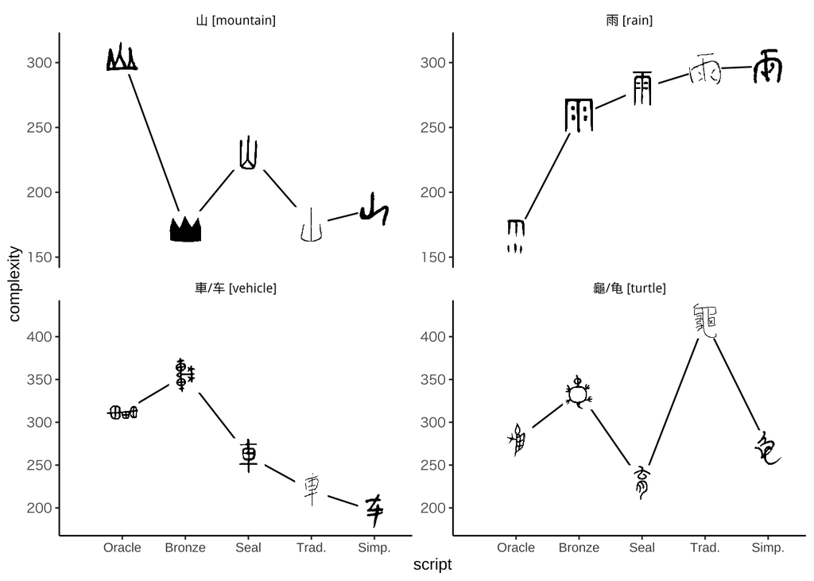

```r
egs = c("山", "雨", "车", "龟")
eglabs = c("山 [mountain]", "雨 [rain]",  "車/车 [vehicle]", "龜/龟 [turtle]")

dsummegs <- dsumm %>%
  filter(character %in% egs) %>%
  mutate(character = factor(character, levels=egs)) %>%
  mutate(demopathprefix = case_when( period == "Traditional" ~ "traditional_handwritten",
                                period == "Simplified" ~  "simplified_handwritten",
                                TRUE ~ "hanziyuan"
                              ))  %>%
  mutate(skeldemopathprefix = case_when( period == "Traditional" ~ "traditional_handwritten_skel",
                                period == "Simplified" ~  "simplified_handwritten_skel",
                                TRUE ~ "hanziyuan_skel"
                              ))  %>%
  mutate(imageloc =  here("figures", "fig1_pieces", demopathprefix, paste0(.$character, "_", .$period, ".png")))  %>%
  mutate(skelimageloc =  here("figures", "fig1_pieces", skeldemopathprefix, paste0(.$character, "_", .$period, ".png")))


egplot_text <- data.frame(
  label = c("Complexity decreases", "Complexity increases", "", ""),
  character = factor(eglabs, levels=eglabs),
  x     = 3,
  y     = 425
)

blank_data <- data.frame(character= c("山", "山", "雨", "雨","车", "车","龟","龟"),
                         x = 0, y = c(150, 315, 150, 315,180,430, 180,430)) %>%
mutate(character = factor(character, levels=egs)) %>%
mutate(character= recode(character, 山 = "山 [mountain]",
                                   雨 = "雨 [rain]",
                                   车 = "車/车 [vehicle]",
                                   龟 = "龜/龟 [turtle]"))

egplot <- dsummegs %>%
  mutate(period = recode(period, Traditional= "Trad.", Simplified = "Simp.")) %>%
  mutate(character= recode(character, 山 = "山 [mountain]",
                                   雨 = "雨 [rain]",
                                   车 = "車/车 [vehicle]",
                                   龟 = "龜/龟 [turtle]")) %>%
  ggplot(aes(period, complexity, group=character)) +
  geom_point() +
  geom_line() +
  geom_blank(data = blank_data, aes(x = x, y = y)) +
  facet_wrap(~character, scales = "free_y") +
  geom_image( aes(x=period, y=0 + complexity, image = imageloc),
              size = 0.15, by = "height", asp = (6+0.5)/4
              ) +
  xlab("script") +
  theme( strip.background = element_blank() )

egplot
```

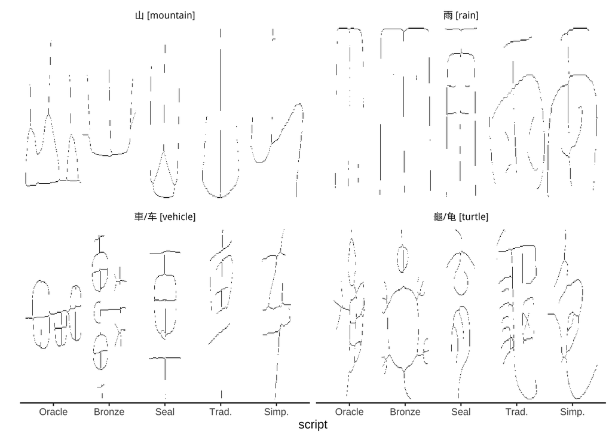

```r
ggsave(here("figures", "fig1_example_changes.pdf"), plot = egplot, width = 6,height = 4)

skelplot <- dsummegs %>%
  mutate(period = recode(period, Traditional= "Trad.", Simplified = "Simp.")) %>%
  mutate(character= recode(character, 山 = "山 [mountain]",
                                   雨 = "雨 [rain]",
                                   车 = "車/车 [vehicle]",
                                   龟 = "龜/龟 [turtle]")) %>%
  ggplot(aes(period, 0, group=character)) +
  facet_wrap(~character) +
  geom_image( aes(x=period, y=0, image = skelimageloc),
              size = 0.2, by = "width", asp = (6+4)/2    # had to adjust by hand
              ) +

  theme(
  strip.background = element_blank(),
  #strip.text.x = element_blank(),
  axis.line.y = element_blank()
  )  +
  scale_y_discrete(labels = NULL, breaks = NULL) + labs(y = "") +
  xlab("script")

skelplot
```

```r
ggsave(here("figures", "figs1_example_changes_skel.pdf"), plot = skelplot, width = 6,height = 2)
```

### Changes in complexity over time

Make Figure 2

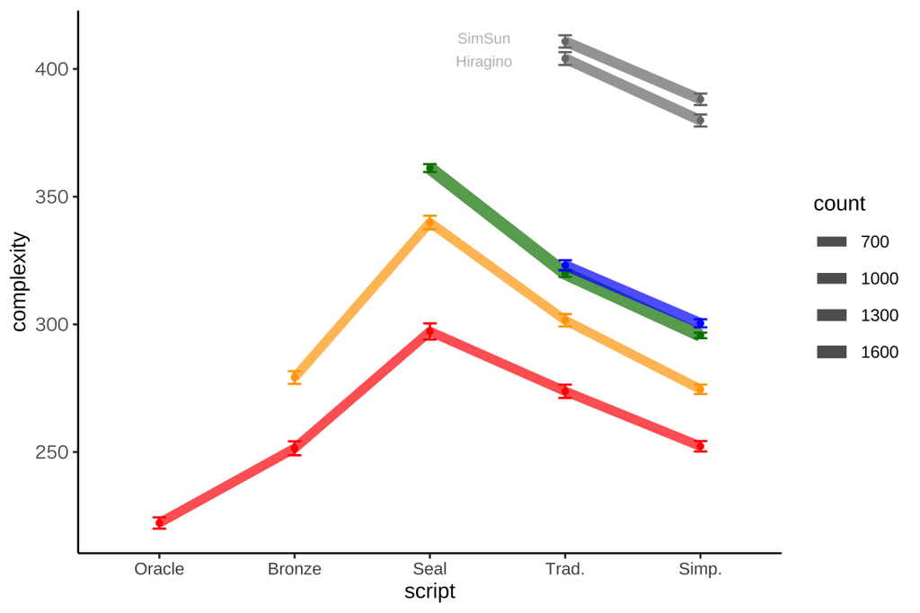

```r
dmeans <- dsumm %>%
  bind_rows(d_font) %>%
  mutate(first= factor(first, levels=periods_font, order=TRUE)) %>%
  filter(first != "Simplified") # drop the "Simplified stream" (the 35 characters that appear first in the Simplified script)

plot_complexity_change <- function(dmeans) {
  dmeans <- dmeans %>%
    mutate(first= factor(first, levels=periods_font, order=TRUE)) %>%
    filter(period %in% periods) %>%
    group_by(period, first) %>%
    dplyr::summarize( n=sum(!is.na(complexity)), sd = sd(complexity, na.rm=TRUE), se=sd/sqrt(n), complexity=mean(complexity, na.rm=TRUE), .groups="drop")  %>%
    group_by(first) %>%
    mutate(n = mean(n))

  dmmax <- 1701
  dmmin <- 600
  scalefactor <- 600

  fig2 <- dmeans %>%
    mutate(period = recode(period, Traditional= "Trad.", Simplified = "Simp.")) %>%
    ggplot(aes(x=period, y=complexity, group=first, color=first,size=n))+
    geom_line(alpha = 0.7) +
    geom_point(alpha = 1.0, size=1) +
    geom_errorbar(aes(ymin=complexity-se, ymax=complexity+se), size = 0.5 , width=0.1, size = 0.01) +
    scale_size_continuous(range = c(dmmin/scalefactor,dmmax/scalefactor), name="count", breaks = c(700, 1000, 1300,1600), limits = c(10, 1701)) +
    #theme(legend.position = c(0.15, 0.82)) +
    xlab("script")
}

fig2_tradstream <- plot_complexity_change(dmeans) +
    scale_color_manual(values = period_col, guide='none')  +
    annotate(geom="text", x = 3.4, y = 412,label = "SimSun" , color = "grey", size = 2.5) +
    annotate(geom="text", x = 3.4, y = 403,label = "Hiragino" , color = "grey", size = 2.5)

fig2_tradstream
```

```r
ggsave(here("figures", "fig2_complexitythroughtime.pdf"), plot = fig2_tradstream, width = 3.4252,height = 2.8)
```

### Behavioral Experiment

Make Figure 3c

```r
dpathfont <- here("experiment", "data", "data_pictographic_ratings_oracle_printedtraditional.csv")
dpathhw <- here("experiment", "data", "data_pictographic_ratings_oracle_hwtraditional.csv")

dall <- read_csv(dpathfont) %>%
  bind_rows(read_csv(dpathhw)) %>%
  mutate(origcondition = condition) %>%
  mutate(condition = if_else(condition=="traditional", "printed", "handwritten"))

dexp <- dall %>%
 filter(controlscore == 5) %>%
 mutate(binrating=rating>2.5) %>%
 mutate(rating = rating - 2.5) %>%
 filter(!str_detect(character, "^control_")) %>%
 group_by(condition, character) %>%
 mutate(cmean = mean(rating))

cc = converter(S2T)

expsumm <- dexp %>%
  select(character, condition, cmean) %>%
  unique() %>%
  group_by(condition) %>%
  mutate(r = rank(cmean)) %>%
  mutate(plotlab = if_else(character %in% c("山", "车", "雨", "龟"), character, '')) %>%
  mutate(plotlab =  run_convert(cc, plotlab) )

expsummnolab <- expsumm %>%
  filter(plotlab == "")

expsummlab <- expsumm %>%
  filter(plotlab != "")

humanfig <- expsummnolab %>%
  ggplot(aes(condition, cmean, label=plotlab)) +
  geom_violin() +
  geom_hline(yintercept=0, color="black", size=0.1) +
  stat_summary(fun = mean, geom="crossbar", fatten=0.5) +
  geom_point(alpha=1.0, width=0.2, colour="gray", size=0.1, position = position_jitter(seed = 0))+
  geom_point(data = expsummlab, alpha=1.0, width=0.2, colour="gray", size=0.1)+
  geom_text_repel(data = expsummlab, direction = "y", size=2,  box.padding = 0.1, nudge_y = 0.001)+
  stat_summary(fun.data=mean_se, geom="errorbar", width=0.15)+
  ylim(-2.0, 2.5) +
  ylab('complexification (human rating)')
```

### Character type, Number of Components

Make Figures 3a and 3b

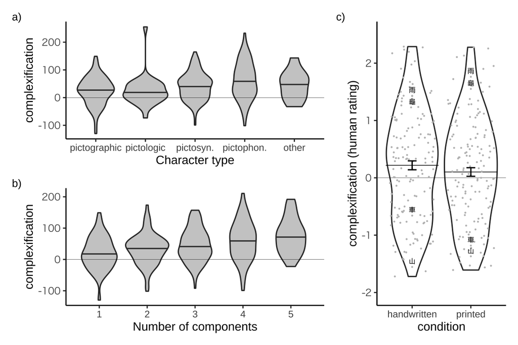

```r
d_trad_vs_ob <- dsumm %>%
  select(character, rendered_character, period, first, complexity, C1Type, numcomp) %>%
  pivot_wider(names_from=period, values_from=complexity) %>%
  mutate(complexification= Traditional - Oracle) %>%
  select(character, C1Type, complexification, numcomp)

fig3a <- d_trad_vs_ob %>%
  filter(numcomp <= 5) %>%
  ggplot(aes(x=numcomp, y=complexification, group=numcomp))+
  geom_violin(fill="gray80", draw_quantiles = c(0.5)) +
  geom_hline(yintercept=0, color="black", size=0.1) +
  xlab("Number of components")

fig3b <- d_trad_vs_ob %>%
  ggplot(aes(x=C1Type, y=complexification, group=C1Type))+
  geom_violin(fill="gray80", draw_quantiles = c(0.5)) +
  geom_hline(yintercept=0, color="black", size=0.1) +
  xlab("Character type") +
  plot_annotation(tag_levels = c('a'), tag_suffix = ')')  +
  theme(plot.tag = element_text(size = 9))

patchl <- fig3b / fig3a +
  plot_annotation(tag_levels = c('a'), tag_suffix = ') ')  +
  theme(plot.tag = element_text(size = 9))

patchlprint <- patchl +
  plot_annotation(tag_levels = c('a'), tag_suffix = ') ')  +
  theme(plot.tag = element_text(size = 9))

patch2 <- patchl  | humanfig

patch2print <- patch2 +
  plot_annotation(tag_levels = c('a'), tag_suffix = ') ')  +
  theme(plot.tag = element_text(size = 9)) +
  plot_layout(widths=c(2,1))

patch2print
```

```r
ggsave(here("figures", "fig3.pdf"), plot = patch2print, width = 6.0, height = 2.8)
```

## Distinctiveness

Make Figures 6 and S13. See `near_neighbours.Rmd` for code that creates Fig S12

```r
d_dim_all_withfont <-  read_csv(here('data', 'distinctiveness', 'all_distinctiveness.csv'))  %>%
  select(-...1) %>%
  rename(character = simplified_character, complexity = perimetric_complexity) %>%
  mutate(period = factor(period, levels=periods, order=TRUE))  %>%
  mutate(dataset= factor(dataset, levels=datasets, order=TRUE)) %>%
  group_by(character) %>%
  mutate(first = min(period)) %>%
  mutate(first_dataset = min(dataset)) %>%
  ungroup()

d_dim_all <- d_dim_all_withfont %>%
  #strip fonts
  filter(!(dataset %in% c("SimSun", "Hiragino Sans GB")))

distinct_summ_withfont <- d_dim_all_withfont %>%
  group_by(period, dataset) %>%
  summarize(n = n(), complexity = median(complexity), distinctiveness = median(distinctiveness))

complexity_only <- d_dim_all %>%
  select(character, period, dataset, complexity)

d_dim_streams <-  read_csv(here('data', 'distinctiveness', 'all_distinctiveness_streamed.csv'))  %>%
  rename(character = simplified_character, first = period_stream) %>%
  left_join(complexity_only, by = c("character", "period", "dataset")) %>%
  left_join(d_cld_freqs, by = "character") %>%
  mutate(period = factor(period, levels=periods, order=TRUE)) %>%
  filter(first != "Simplified") %>% # drop the "simplified stream" (ie the 35 characters that only appear in the simplified dataset) %>%
  filter( !(dataset %in% c("Hiragino Sans GB", "SimSun")) | first == "Traditional") %>%  # only keep Traditional stream for fonts
  mutate(first= case_when(dataset == "Hiragino Sans GB" ~ "Hiragino",
                          dataset == "SimSun" ~ "SimSun",
                          TRUE ~ first)) %>%
  mutate(first= factor(first, levels=periods_font, order=TRUE))

# counts for distinctiveness streams (right part of Table S1)

script_counts_distinctiveness <-  d_dim_streams %>%
  select(character, period, dataset, first) %>%
  unique() %>%
  group_by(period, dataset, first) %>%
  summarize(n=n(), .groups = "drop") %>%
  arrange(first)

kable(script_counts_distinctiveness)
```

| period | dataset | first | n |
| --- | --- | --- | --- |
| Oracle | hzy | Oracle | 491 |
| Bronze | hzy | Oracle | 491 |
| Seal | hzy | Oracle | 491 |
| Traditional | traditional | Oracle | 491 |
| Simplified | casia | Oracle | 491 |
| Bronze | hzy | Bronze | 578 |
| Seal | hzy | Bronze | 578 |
| Traditional | traditional | Bronze | 578 |
| Simplified | casia | Bronze | 578 |
| Seal | hzy | Seal | 1692 |
| Traditional | traditional | Seal | 1692 |
| Simplified | casia | Seal | 1692 |
| Traditional | traditional | Traditional | 857 |
| Simplified | casia | Traditional | 857 |
| Traditional | SimSun | SimSun | 857 |
| Simplified | SimSun | SimSun | 857 |
| Traditional | Hiragino Sans GB | Hiragino | 857 |
| Simplified | Hiragino Sans GB | Hiragino | 857 |

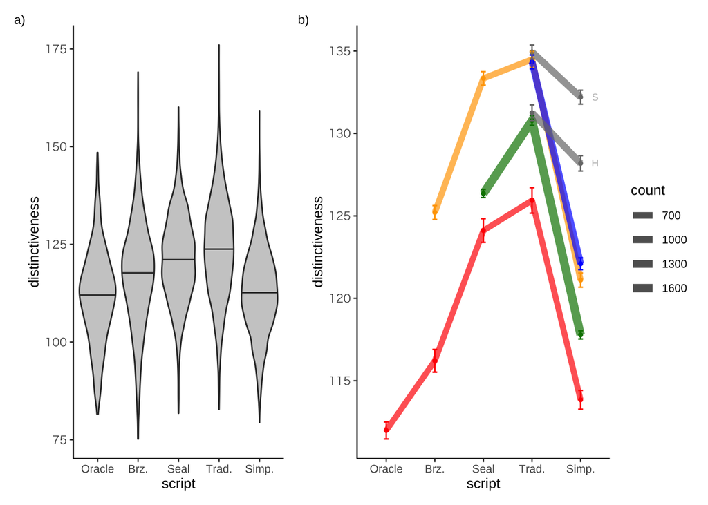

```r
blank_data_d <- data.frame(period= periods,  x = 30, y =185) %>%
  mutate(period = ordered(period, levels = periods))

fig_d <- d_dim_all %>%
  ggplot(aes(x=complexity, y=distinctiveness)) +
  geom_point(size = 0.01, aes(colour=period))  +
  geom_smooth(method="lm", size = 0.5)  +
  facet_wrap(~period) +
  ylab("distinctiveness") +
  stat_cor(
    aes(label = ..r.label..),
    cor.coef.name='r',
    label.x.npc = 0.225,
    label.y.npc = 1.0,
    size = 2.0
  ) +
  geom_blank(data = blank_data_d, aes(x = x, y = y)) +
  scale_x_continuous(breaks = c(10,30,50)) +
  #plot_annotation(tag_levels = c('a'), tag_suffix = ') ')  +
  theme(plot.tag = element_text(size = 9)) +
  scale_color_manual(values = period_col, guide='none')

fig_d_change <- d_dim_all %>%
  mutate(period = recode(period, Bronze = "Brz.", Traditional= "Trad.", Simplified = "Simp.")) %>%
  ggplot(aes(x=period, y=distinctiveness)) +
  geom_violin(fill="gray80", draw_quantiles = c(0.5)) +
  ylab("distinctiveness") +
  plot_annotation(tag_levels = c('a'), tag_suffix = ') ')  +
  theme(plot.tag = element_text(size = 9)) +
  xlab("script")

dmeans <- d_dim_streams %>%
  group_by(period, first) %>%
  dplyr::summarize( n=n(), sd = sd(complexity), sdd = sd(distinctiveness), se=sd/sqrt(n), sed = sdd/sqrt(n), complexity=mean(complexity), distinctiveness=mean(distinctiveness), .groups="drop")

dmmax <- 1701
dmmin <- 600
scalefactor <- 600

fig_dstream <- dmeans %>%
  mutate(period = recode(period, Bronze = "Brz.", Traditional= "Trad.", Simplified = "Simp.")) %>%
  ggplot(aes(x=period, y=distinctiveness, group=first, color=first,size=n))+
  geom_line(alpha = 0.7) +
  geom_point(alpha = 1.0, size=1) +
  geom_errorbar(aes(ymin=distinctiveness-sed, ymax=distinctiveness+sed), size = 0.5 , width=0.1) +
  #facet_wrap(~first) +
  scale_color_manual(values = period_col, guide='none') +
  scale_size_continuous(range = c(dmmin/scalefactor,dmmax/scalefactor), name="count", breaks = c(700,1000, 1300, 1600), limits = c(10, 1701))  +
  xlab("script") +
  annotate(geom="text", x = 5.3, y = 132.2,label = "S" , color = "grey", size = 2.5) +
  annotate(geom="text", x = 5.3, y = 128.2,label = "H" , color = "grey", size = 2.5)

dprint <- { fig_d_change | fig_dstream  } +
  plot_annotation(tag_levels = c('a'), tag_suffix = ') ')  +
  theme(plot.tag = element_text(size = 9))  +
  plot_layout(widths=c(5,6))

dprint
```

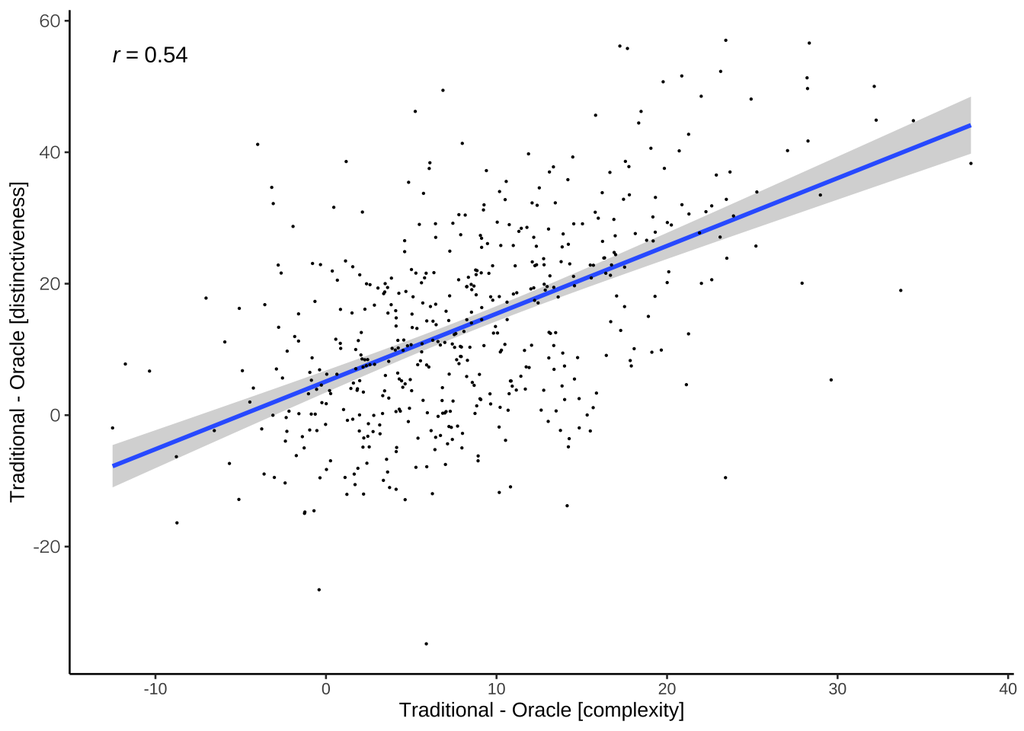

```r
ggsave(here("figures","fig6_distinctiveness_changes.pdf"), plot = dprint, width = 6,height = 2.5)

# Fig S13: distinctiveness, complexity. time in one plot

dctdata <- d_dim_streams %>%
  filter(first == 'Oracle') %>%
  filter(period == "Oracle" | period == "Traditional") %>%
  select(character, period, complexity, distinctiveness) %>%
  pivot_wider(names_from=c(period), values_from=c(complexity, distinctiveness)) %>%
  mutate(complexitydiff = complexity_Traditional - complexity_Oracle, distinctivenessdiff = distinctiveness_Traditional - distinctiveness_Oracle)

dctplot <- dctdata %>%
  ggplot(aes(x=complexitydiff, y=distinctivenessdiff)) +
  stat_smooth(method = "lm") +
  geom_point(size = 0.1)  +
  ylab("Traditional - Oracle [distinctiveness]")+
  xlab("Traditional - Oracle [complexity]")+
  stat_cor( aes(label = ..r.label..), cor.coef.name='r')
dctplot
```

```r
ggsave(here("figures", "figs13_distinctiveness_complexity_changes.pdf"), plot = dctplot,  width=3,height = 3)
```

## Tradeoff between complexity and distinctiveness

Generate Figure 5. A random seed was not set before generating the samples for Figures 5b and 5c in the paper, so those figures will not be identical to the versions generated here.

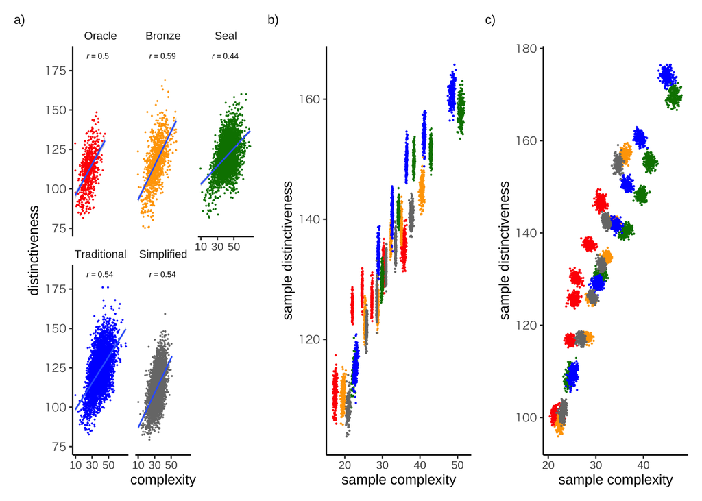

```r
d_tr_c <- read_csv(dpath_tradeoff_bincomplexity)
d_tr_d <- read_csv(dpath_tradeoff_bindistinct)

plot_tradeoff <- function(d_tr) {
  plot_dc <- d_tr %>%
    mutate(script= factor(period, levels=periods, order=TRUE)) %>%
    ggplot(aes(x = sample_average_complexity, y=sample_average_distinctiveness, color = script)) +
    geom_point(size=0.1) +
    scale_color_manual(values = period_col, guide="none")  +
    xlab('sample complexity')  +
    ylab('sample distinctiveness')  +
    theme(plot.tag = element_text(size = 9))
}

plot_dc_c <- plot_tradeoff(d_tr_c)
plot_dc_d <- plot_tradeoff(d_tr_d)

dprint <- { fig_d | plot_dc_c | plot_dc_d} +
  plot_annotation(tag_levels = c('a'), tag_suffix = ') ')  +
  theme(plot.tag = element_text(size = 9))+
  plot_layout(widths=c(1.25,1,1))

dprint
```

```r
ggsave(here("figures","fig5_distinctiveness_tradeoff.pdf"), plot = dprint, width = 7,height = 2.5)
```

## Frequency

Figures 4 and S9 are generated by `Figure 4.ipynb`. Here we plot level curves of Figure 4.

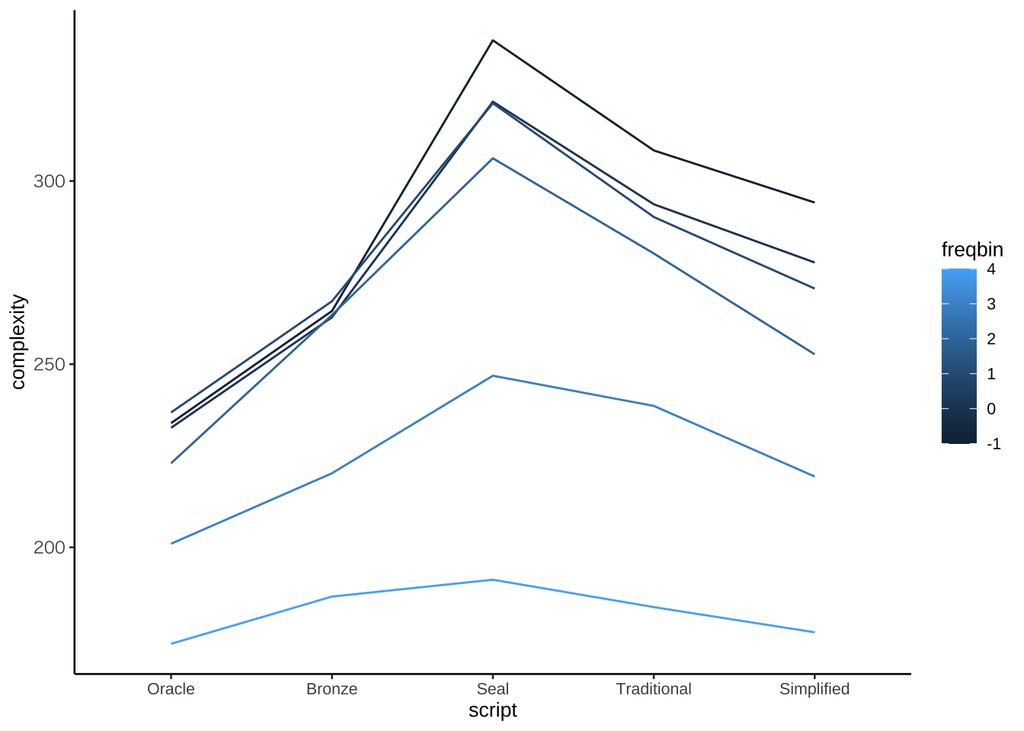

```r
complexity_freq <- dsumm %>%
  filter(first == 'Oracle') %>%
  mutate(freqbin_true= -floor(log10(frequency))) %>%
  # to avoid small groups at extremes of frequency scale
  mutate(freqbin = case_when(freqbin_true <= -4 ~ -4,
                             freqbin_true >= 1  ~ 1,
                             TRUE ~ freqbin_true)) %>%
  group_by(period, freqbin) %>%
  dplyr::summarize(complexity = mean(complexity), n = n()) %>%
  drop_na()

distinct_freq <- d_dim_streams  %>%
  filter(first == 'Oracle') %>%
  mutate(freqbin_true= -floor(log10(frequency))) %>%
  # to avoid small groups at extremes of frequency scale
  mutate(freqbin = case_when(freqbin_true <= -4 ~ -4,
                             freqbin_true >= 1  ~ 1,
                             TRUE ~ freqbin_true)) %>%
  group_by(period, freqbin) %>%
  dplyr::summarize(distinctiveness= mean(distinctiveness), n = n())


wf <- wireframe(complexity ~ freqbin * period,
          data = complexity_freq,
          screen = list(z = 45, x=-60),
          )

freqplot_complex <- complexity_freq %>%
  mutate(freqbin = -freqbin) %>%
  ggplot(aes(x=period, y=complexity, group=freqbin, color=freqbin)) +
  geom_line() +
  xlab("script")
freqplot_complex
```

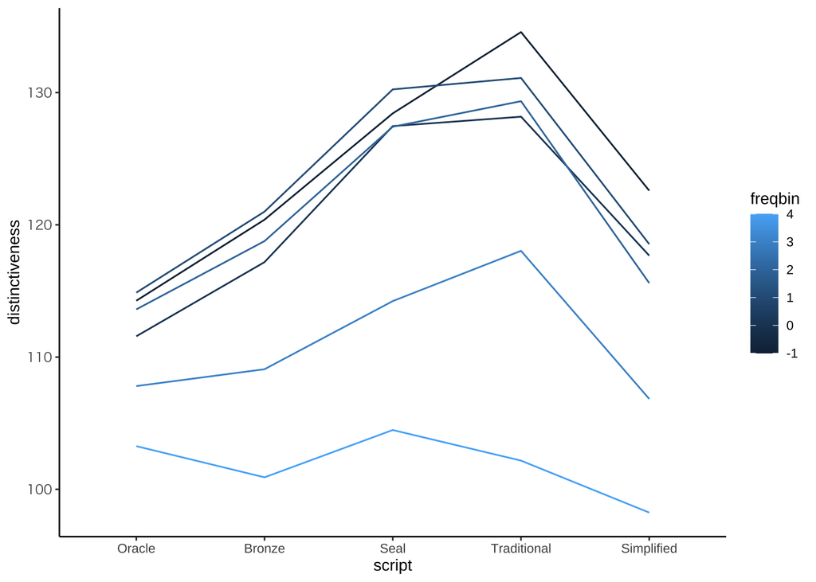

```r
freqplot_distinct <- distinct_freq %>%
  mutate(freqbin = -freqbin) %>%
  ggplot(aes(x=period, y=distinctiveness, group=freqbin, color=freqbin)) +
  geom_line() +
  xlab("script")
freqplot_distinct
```

## Alternative complexity measures

This section generates Figure S17. See `descriptive_complexity.Rmd` for code that generates Figure S18.

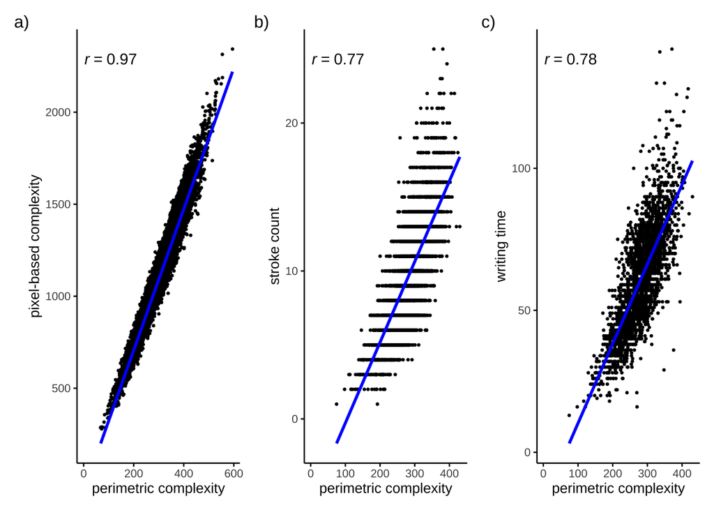

```r
d_sc <- dsumm %>%
  filter(period=="Simplified") %>%
  mutate(pixcomplexity=stroke_count)

d_gif <-  read_csv(dpath_gif) %>%
  right_join(d_sc, by = "rendered_character") %>%
  mutate(pixcomplexity=stroke_gif_complexity)

myscatter <- function(d) {
  pixcomplexity <- d %>%
    ggscatter(x = "complexity", y = "pixcomplexity",
    size = 0.5,
    add = "reg.line",
    add.params = list(color = "blue", fill = "lightgray"),
    ggtheme = mytheme
  ) +
  stat_cor(
    aes(label = ..r.label..),
    label.x = 3,
    cor.coef.name='r'
  )  + #+ coord_fixed(ratio=2)
  xlab('perimetric complexity')

  return(pixcomplexity)
}

pixcomplexity  <- myscatter(dsumm) +
  ylab('pixel-based complexity')

strokecount<- myscatter(d_sc) +
  ylab('stroke count')

gifcomplexity<- myscatter(d_gif) +
  ylab('writing time')

altcomplex <- pixcomplexity + strokecount + gifcomplexity +
  plot_annotation(tag_levels = c('a'), tag_suffix = ')')

altcomplex
```

```r
ggsave(here("figures", "figs17_alt_complexity_measures.pdf"), plot = altcomplex,  width=7.08661,height = 2.8)
```

## Statistical analyses

First run analyses of changes in complexity over time

```r
# Based in part on
#https://github.com/paul-buerkner/monotonic-effects-paper/blob/master/monotonic_effects.Rmd

sdif_coding <- function(x) {
  x <- as.factor(x)
  contrasts(x) <- MASS::contr.sdif(levels(x))
  x
}

dsumm_brm <- dsumm %>%
  mutate(periodl = as.numeric(period)) %>%
  mutate(periodc = sdif_coding(factor(period))) %>%
  select(character, period, periodl, periodc, complexity, first, logfrequency, logfrequencyscale, logfrequencyraw, logfrequencyrawscale)

nchain <- 4

fit3 <- brm( complexity ~ periodc + (1 + period| character), data = dsumm_brm, chains = nchain)
```

```r
pme3 <- plot(conditional_effects(fit3), plot = FALSE, ask = FALSE)

coefnames <- fixef(fit3) %>% rownames()
coefsamples <- fixef(fit3, summary=FALSE, pars=coefnames[-1]) %>%
  as_tibble() %>%
  rename("Bronze-Oracle"=periodcBronzeMOracle, "Seal-Bronze"=periodcSealMBronze, "Traditional-Seal"=periodcTraditionalMSeal, "Simplified-Traditional"=periodcSimplifiedMTraditional)
postplot <- mcmc_areas(coefsamples)

ggsave(here("figures", "figs2_bayesreg_period.pdf"), plot = postplot,  width=4,height = 2.8)

tableout<- xtable(fixef(fit3), caption = "Coefficients for period regression" )
print(tableout, file = here("tables", "coeftable_periodregression.tex"))
```

### Frequency and complexity

```r
dsumm_brm_freq <- dsumm_brm %>%
  filter(first=="Oracle") %>%   # only characters in Oracle stream
  filter(!is.na(logfrequency)) %>%
  mutate(rarity= -logfrequencyscale) %>%
  mutate(rarityraw= -logfrequencyrawscale) %>%
  mutate(periodc = sdif_coding(factor(period)))

# adjusted frequency is the default
for (freqsuffix in c("", "raw")) {
  dsumm_forstats <- dsumm_brm_freq %>%
    mutate(rarity = !!as.symbol(paste0("rarity", freqsuffix)))

  dsumm_forstats_tradonly <- dsumm_forstats %>%
    filter(period %in% c("Oracle", "Traditional")) %>%
    mutate(periodc = sdif_coding(factor(period)))

  assign(paste0("fit3_freq", freqsuffix), brm( complexity ~ periodc + rarity + periodc*rarity + (1 + period| character), data = dsumm_forstats, chains = nchain) )

  assign(paste0("fit3_freq_tradonly", freqsuffix), brm( complexity ~ periodc + rarity + periodc*rarity + (1 + period| character), data = dsumm_forstats_tradonly, chains = nchain) )
}
```

```r
for (freqsuffix in c("", "raw")) {
  fit3freq_thissuffix <- get(paste0("fit3_freq", freqsuffix))
  fit3freq_tradonly_thissuffix  <-  get(paste0("fit3_freq_tradonly", freqsuffix))

  coefnames <- fixef(fit3freq_thissuffix) %>% rownames()
  coefsamples <- fixef(fit3freq_thissuffix, summary=FALSE, pars=coefnames[-1]) %>%
    as_tibble() %>%
    rename("Bronze-Oracle"=periodcBronzeMOracle,
           "Seal-Bronze"=periodcSealMBronze,
           "Traditional-Seal"=periodcTraditionalMSeal,
           "Simplified-Traditional"=periodcSimplifiedMTraditional,
           "(Bronze-Oracle):rarity"="periodcBronzeMOracle:rarity",
           "(Seal-Bronze):rarity"="periodcSealMBronze:rarity",
           "(Traditional-Seal):rarity"="periodcTraditionalMSeal:rarity",
           "(Simplified-Traditional):rarity"="periodcSimplifiedMTraditional:rarity",
           )

  postplot <- mcmc_areas(coefsamples)

  ggsave(here("figures", paste0("figs7_s10_bayesreg_freq", freqsuffix, ".pdf")), plot = postplot,  width=5,height = 5)

  tableout<- xtable(fixef(fit3freq_thissuffix), caption = "Coefficients for frequency regression" )
  print(tableout, file = here("tables", paste0("coeftable_frequencyregression", freqsuffix, ".tex")))

  coefnames <- fixef(fit3freq_tradonly_thissuffix) %>% rownames()
  coefsamples <- fixef(fit3freq_tradonly_thissuffix, summary=FALSE, pars=coefnames[-1]) %>%
    as_tibble() %>%
    rename("Traditional-Oracle"=periodcTraditionalMOracle,
           "(Traditional-Oracle):rarity"="periodcTraditionalMOracle:rarity",
           )
  postplot <- mcmc_areas(coefsamples)
  ggsave(here("figures", paste0("figs8_s11_bayesreg_freq_tradonly", freqsuffix, ".pdf")), plot = postplot,  width=5,height = 2.5)

  tableout<- xtable(fixef(fit3freq_tradonly_thissuffix), caption = "Coefficients for frequency regression (oracle vs traditional)" )
  print(tableout, file = here("tables",  paste0("coeftable_frequencyregression_tradonly", freqsuffix, ".tex")))
}
```

### Character type, number of components

```r
fit3_ctype <- brm( complexification ~ 0+C1Type, data = d_trad_vs_ob, chains = nchain )
d_trad_vs_ob_smallcomp <- d_trad_vs_ob %>%
  filter(numcomp <= 5) %>%
  mutate(numcomp = factor(numcomp))

fit3_numcomp <- brm( complexification ~ 0+numcomp, data = d_trad_vs_ob_smallcomp, chains = nchain)
```

```r
coefnames <- fixef(fit3_ctype) %>% rownames()
coefsamples <- fixef(fit3_ctype, summary=FALSE, pars=coefnames) %>%
  as_tibble() %>%
  rename("pictographic"="C1Typepictographic",
         "pictologic"="C1Typepictologic",
         "pictosyn"="C1Typepictosyn.",
         "pictophon"="C1Typepictophon.",
         "other"="C1Typeother")

postplot_ctype <- mcmc_areas(coefsamples) +
                  xlab('complexification')

tableout<- xtable(fixef(fit3_ctype), caption = "Coefficients for ctype regression" )
print(tableout, file = here("tables", "coeftable_ctype.tex"))

coefnames <- fixef(fit3_numcomp) %>% rownames()
coefsamples <- fixef(fit3_numcomp, summary=FALSE, pars=coefnames) %>%
  as_tibble() %>%
  rename("1 comp"="numcomp1",
         "2 comp"="numcomp2",
         "3 comp"="numcomp3",
         "4 comp"="numcomp4",
         "5 comp"="numcomp5")

postplot_numcomp <- mcmc_areas(coefsamples) +
                  xlab('complexification')

tableout<- xtable(fixef(fit3_numcomp), caption = "Coefficients for numcomp regression" )
print(tableout, file = here("tables", "coeftable_numcompregression.tex"))

posteriors <- postplot_ctype + postplot_numcomp +
    plot_annotation(tag_levels = c('a'), tag_suffix = ')')  +
    theme(plot.tag = element_text(size = 9))

ggsave(here("figures", "figs6_bayesreg_ctype.pdf"), plot = posteriors, width = 7.08661,height = 3.5)
```

### Distinctiveness through time

```r
dsumm_brm_d <- d_dim_all %>%
  mutate(periodc = sdif_coding(factor(period)))

fit_d <- brm( distinctiveness ~ periodc + (1 + period| character), data = dsumm_brm_d, chains = nchain)
```

```r
pme3 <- plot(conditional_effects(fit_d), plot = FALSE, ask = FALSE)

coefnames <- fixef(fit_d) %>% rownames()
coefsamples <- fixef(fit_d, summary=FALSE, pars=coefnames[-1]) %>%
  as_tibble() %>%
  rename("Bronze-Oracle"=periodcBronzeMOracle, "Seal-Bronze"=periodcSealMBronze, "Traditional-Seal"=periodcTraditionalMSeal, "Simplified-Traditional"=periodcSimplifiedMTraditional)
postplot <- mcmc_areas(coefsamples)

ggsave(here("figures", "figs14_bayesreg_period_distinctiveness.pdf"), plot = postplot,  width=4,height = 2.8)

tableout<- xtable(fixef(fit_d), caption = "Coefficients for period regression (distinctiveness)" )
print(tableout, file = here("tables",  "coeftable_periodregression_distinctiveness.tex"))
```

### Frequency and distinctiveness

```r
dsumm_brm_freq_distinct <- d_dim_streams %>%
  filter(first=="Oracle") %>%   # only characters in Oracle stream
  mutate(periodl = as.numeric(period)) %>%
  mutate(periodc = sdif_coding(factor(period))) %>%
  select(character, period, periodl, periodc, distinctiveness, first, logfrequency, logfrequencyscale) %>%
  filter(!is.na(logfrequency)) %>%
  mutate(rarity= -logfrequencyscale)

# adjusted frequency is the default
for (freqsuffix in c("")) {
  dsumm_forstats_distinct <- dsumm_brm_freq_distinct %>%
    mutate(rarity = !!as.symbol(paste0("rarity", freqsuffix)))

  dsumm_forstats_tradonly_distinct <- dsumm_forstats_distinct %>%
    filter(period %in% c("Oracle", "Traditional")) %>%
    mutate(periodc = sdif_coding(factor(period)))

  assign(paste0("fit3_freq_distinct", freqsuffix), brm( distinctiveness ~ periodc + rarity + periodc*rarity + (1 + period| character), data = dsumm_forstats_distinct, chains = nchain) )
}
```

```r
for (freqsuffix in c("")) {
  fit3freq_thissuffix <- get(paste0("fit3_freq_distinct", freqsuffix))

  coefnames <- fixef(fit3freq_thissuffix) %>% rownames()
  coefsamples <- fixef(fit3freq_thissuffix, summary=FALSE, pars=coefnames[-1]) %>%
    as_tibble() %>%
    rename("Bronze-Oracle"=periodcBronzeMOracle,
           "Seal-Bronze"=periodcSealMBronze,
           "Traditional-Seal"=periodcTraditionalMSeal,
           "Simplified-Traditional"=periodcSimplifiedMTraditional,
           "(Bronze-Oracle):rarity"="periodcBronzeMOracle:rarity",
           "(Seal-Bronze):rarity"="periodcSealMBronze:rarity",
           "(Traditional-Seal):rarity"="periodcTraditionalMSeal:rarity",
           "(Simplified-Traditional):rarity"="periodcSimplifiedMTraditional:rarity",
           )

  postplot <- mcmc_areas(coefsamples)

  ggsave(here("figures", paste0("figs16_bayesreg_freq_distinct", freqsuffix, ".pdf")), plot = postplot,  width=5,height = 5)

  tableout<- xtable(fixef(fit3freq_thissuffix), caption = "Coefficients for frequency regression" )
  print(tableout, file = here("tables", paste0("coeftable_frequencyregression_distinct", freqsuffix, ".tex")))
}
```